# R Notebook

Os dados descrevem 5000 encontros relâmpagos (speed dating, procura no google) de 4 minutos envolvendo 310 jovens americanos. Os dados originais foram coletados por professores da Columbia Business School no experimento descrito aqui. Nesta análise estamos usando uma versão com menos atributos que pode ser encontrado aqui. Os atributos selecionado são:

- gender : sexo do participante 1, 0 = mulher e 1 = homem
- diff_agr : diferença de idade entre participante 1 e o participante 2
- attr : quão atraente o participante 1 achou o participante 2
- fun : quão divertido o participante 1 achou o participante 2

Os participantes tinham vários encontros de 4 minutos por noite. Após cada um, preenchiam fichas avaliando aqueles com quem se encontraram. Cada linha nos dados representa um desses encontros.

Nesta análise vamos utilizar regressão logística em um conjunto nestas 4 variáveis explicativas para responder quais fatores nos dados têm efeito relevante na chance do casal ter um match?

```r
library(tidyverse)
library(tidyr)
library(stargazer)
library(caret)

speed_dating = read_csv("dados/speed-dating2.csv") %>%
  select(dec, gender, age, age_o, fun, attr, fun) %>%
  mutate(diff_age = age - age_o,
         dec = case_when( .$dec == "no" ~ 0,
                          .$dec == "yes" ~ 1)) %>%
  select(-age, -age_o)
```

```r
regEq <- function(lmObj, dig) {
    paste0("dec = ",
        paste0(
            c(round(lmObj$coef[1], dig), round(sign(lmObj$coef[-1])*lmObj$coef[-1], dig)),
            c("", rep("*", length(lmObj$coef)-1)),
            paste0(c("", names(lmObj$coef)[-1]), c(ifelse(sign(lmObj$coef)[-1]==1," + "," - "), "")),
            collapse=""
        )
    )
}
```

Vamos explorar os dados…

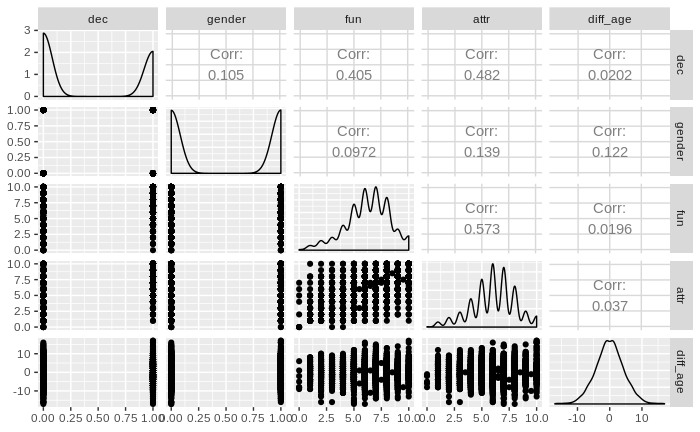

Percebemos que existe correlação entre algumas variáveis. Vamos criar o modelo!

```r
logit <- glm(dec ~ gender + fun + attr + diff_age, data = speed_dating, family = "binomial")
summary(logit)
```

```
Call:
glm(formula = dec ~ gender + fun + attr + diff_age, family = "binomial",
    data = speed_dating)

Deviance Residuals:
    Min       1Q   Median       3Q      Max
-2.4431  -0.8884  -0.3633   0.9056   3.1425

Coefficients:
             Estimate Std. Error z value Pr(>|z|)
(Intercept) -5.773149   0.192083 -30.055  < 2e-16 ***
gender       0.226416   0.070454   3.214  0.00131 **
fun          0.293149   0.023048  12.719  < 2e-16 ***
attr         0.553066   0.025492  21.695  < 2e-16 ***
diff_age    -0.003392   0.008140  -0.417  0.67688
---
Signif. codes:  0 ‘***’ 0.001 ‘**’ 0.01 ‘*’ 0.05 ‘.’ 0.1 ‘ ’ 1

(Dispersion parameter for binomial family taken to be 1)

    Null deviance: 6309.0  on 4626  degrees of freedom
Residual deviance: 4871.2  on 4622  degrees of freedom
  (291 observations deleted due to missingness)
AIC: 4881.2

Number of Fisher Scoring iterations: 5
```

```r
regEq(logit)
```

```
[1] "dec = -6 + 0*gender + 0*fun + 1*attr - 0*diff_age"
```

```r
library(broom)
tidy(logit, conf.int = TRUE, conf.level = 0.95)
```

| term | estimate | std.error | statistic | p.value | conf.low | conf.high |
| --- | --- | --- | --- | --- | --- | --- |
| (Intercept) | -5.773149408 | 0.192083462 | -30.0554215 | 1.854713e-198 | -6.15525476 | -5.40217510 |
| gender | 0.226415953 | 0.070454024 | 3.2136696 | 1.310504e-03 | 0.08835595 | 0.36457205 |
| fun | 0.293149249 | 0.023048159 | 12.7189877 | 4.638300e-37 | 0.24822203 | 0.33859352 |
| attr | 0.553066142 | 0.025492421 | 21.6953164 | 2.271570e-104 | 0.50361597 | 0.60356618 |
| diff_age | -0.003392061 | 0.008139867 | -0.4167219 | 6.768819e-01 | -0.01935228 | 0.01256384 |

```r
glance(logit)
```

| null.deviance | df.null | logLik | AIC | BIC | deviance | df.residual |
| --- | --- | --- | --- | --- | --- | --- |
| 6308.989 | 4626 | -2435.605 | 4881.209 | 4913.407 | 4871.209 | 4622 |